# rbiips: Tutorial 3

In this tutorial, we will see how to introduce user-defined functions in the BUGS model.

# Statistical model

The statistical model is defined as follows.

$$x_1\sim \mathcal N\left (\mu_0, \frac{1}{\lambda_0}\right )$$

$$y_1\sim \mathcal N\left (h(x_1), \frac{1}{\lambda_y}\right )$$

For $t=2:t_{max}$

$$x_t|x_{t-1} \sim \mathcal N\left ( f(x_{t-1},t-1), \frac{1}{\lambda_x}\right )$$

$$y_t|x_t \sim \mathcal N\left ( h(x_{t}), \frac{1}{\lambda_y}\right )$$

# Statistical model in BUGS language

We describe the model in BUGS language in the file `'hmm_1d_nonlin_fext.bug'`:

```r
model_file = 'hmm_1d_nonlin_fext.bug' # BUGS model filename
cat(readLines(model_file), sep = "\n")
```

```
var x_true[t_max], x[t_max], y[t_max]

data
{
  x_true[1] ~ dnorm(mean_x_init, prec_x_init)
  y[1] ~ dnorm(x_true[1]^2/20, prec_y)
  for (t in 2:t_max)
  {
    x_true[t] ~ dnorm(fext(x_true[t-1],t-1), prec_x)
    y[t] ~ dnorm(x_true[t]^2/20, prec_y)
  }
}


model
{
  x[1] ~ dnorm(mean_x_init, prec_x_init)
  y[1] ~ dnorm(x[1]^2/20, prec_y)
  for (t in 2:t_max)
  {
    x[t] ~ dnorm(fext(x[t-1],t-1), prec_x)
    y[t] ~ dnorm(x[t]^2/20, prec_y)
  }
}
```

Although the nonlinear function `f` can be defined in BUGS language, we choose here to use an external user-defined function `fext`, which will call a R function.

# User-defined functions in R

The BUGS model calls a function `fext`. In order to be able to use this function, one needs to create two functions in R. The first function, called here `f_eval` provides the evaluation of the function.

```r
f_eval <- function(x, k) { .5 * x + 25*x/(1+x^2) + 8*cos(1.2*k) }
```

The second function, `f_dim`, provides the dimensions of the output of `f_eval`, possibly depending on the dimensions of the inputs.

```r
f_dim <- function(x_dim, k_dim) { 1 }
```

3. Load rbiips package

```r
require(rbiips)
```

# General settings

```r
par(bty='l')
light_blue = rgb(.7, .7, 1)
light_red = rgb(1, .7, .7)
```

Set the random numbers generator seed for reproducibility

```r
set.seed(2)
```

# Load model and data

#### Model parameters

```r
t_max = 20
mean_x_init = 0
prec_x_init = 1/5
prec_x = 1/10
prec_y = 1
data = list(t_max=t_max, prec_x_init=prec_x_init,
            prec_x=prec_x, prec_y=prec_y, mean_x_init=mean_x_init)
```

#### Add the user-defined function `fext`

```r
fun_bugs = 'fext'; fun_nb_inputs = 2
fun_dim = f_dim; fun_eval = f_eval
biips_add_function(fun_bugs, fun_nb_inputs, fun_dim, fun_eval)
```

```
* Added function fext
```

#### Compile BUGS model and sample data

```r
sample_data = TRUE # Boolean
model = biips_model(model_file, data, sample_data=sample_data) # Create Biips model and sample data
```

```
* Parsing model in: hmm_1d_nonlin_fext.bug
* Compiling data graph
  Declaring variables
  Graph size: 143
  Sampling data
  Reading data back into data table
  Declaring variables
  Graph size: 144
```

```r
data = model$data()
```

# Biips Sequential Monte Carlo

Let now use Biips to run a particle filter.

#### Parameters of the algorithm

We want to monitor the variable `x`, and to get the filtering and smoothing particle approximations. The algorithm will use 10000 particles, stratified resampling, with a threshold of 0.5.

```r
n_part = 10000 # Number of particles
variables = c('x') # Variables to be monitored
mn_type = 'fs'; rs_type = 'stratified'; rs_thres = 0.5 # Optional parameters
```

#### Run SMC

```r
out_smc = biips_smc_samples(model, variables, n_part,
                      type=mn_type, rs_type=rs_type, rs_thres=rs_thres)
```

```
* Assigning node samplers
* Running SMC forward sampler with 10000 particles
  |**************************************************| 20 iterations in 11.54 s
```

#### Diagnosis of the algorithm

```r
diag_smc = biips_diagnosis(out_smc)
```

```
* Diagnosis of variable: x[1:20]
  Filtering: GOOD
  Smoothing: GOOD
```

#### Summary statistics

```r
summ_smc = biips_summary(out_smc, probs=c(.025, .975))
```

#### Plot Filtering estimates

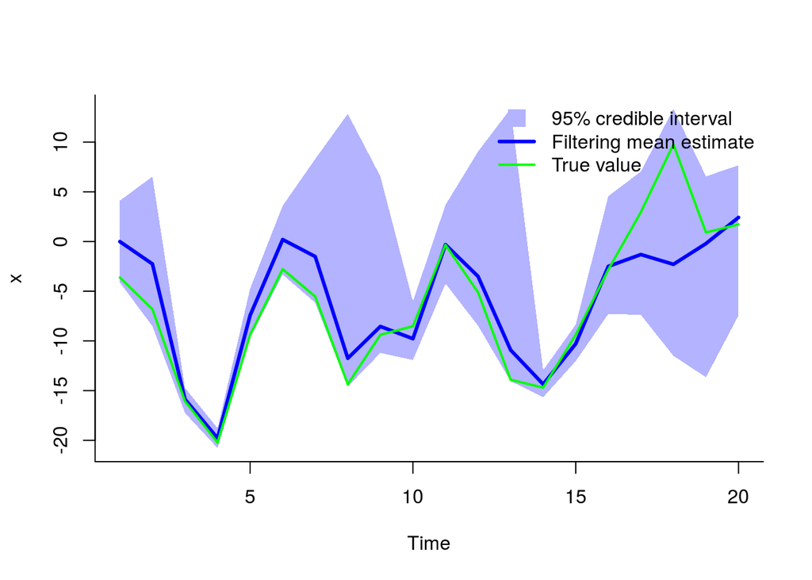

SMC: Filtering estimates

```r
x_f_mean = summ_smc$x$f$mean
x_f_quant = summ_smc$x$f$quant

xx = c(1:t_max, t_max:1)
yy = c(x_f_quant[[1]], rev(x_f_quant[[2]]))
plot(xx, yy, type='n', xlab='Time', ylab='x')

polygon(xx, yy, col=light_blue, border=NA)
lines(1:t_max, x_f_mean, col='blue', lwd=3)
lines(1:t_max, data$x_true, col='green', lwd=2)
legend('topright', leg=c('95% credible interval', 'Filtering mean estimate', 'True value'),
       col=c(light_blue,'blue','green'), lwd=c(NA,3,2), pch=c(15,NA,NA), pt.cex=c(2,1,1), bty='n')
```

#### Plot Smoothing estimates

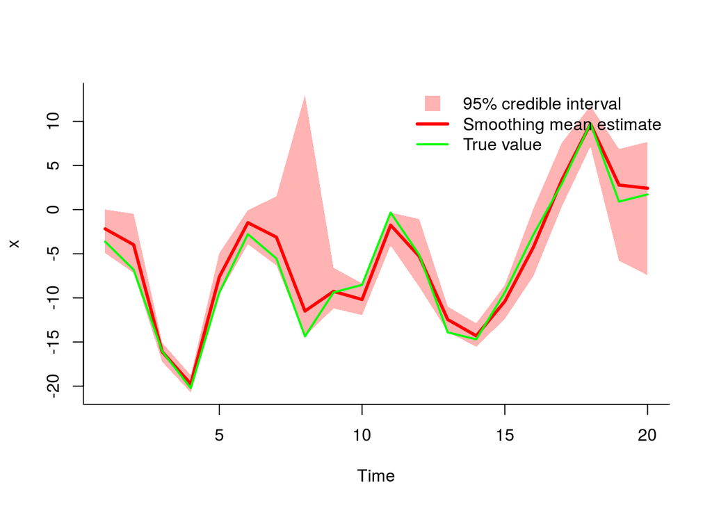

SMC: Smoothing estimates

```r
x_s_mean = summ_smc$x$s$mean
x_s_quant = summ_smc$x$s$quant

xx = c(1:t_max, t_max:1)
yy = c(x_s_quant[[1]], rev(x_s_quant[[2]]))
plot(xx, yy, type='n', xlab='Time', ylab='x')

polygon(xx, yy, col=light_red, border=NA)
lines(1:t_max, x_s_mean, col='red', lwd=3)
lines(1:t_max, data$x_true, col='green', lwd=2)
legend('topright', leg=c('95% credible interval', 'Smoothing mean estimate', 'True value'),
       col=c(light_red,'red','green'), lwd=c(NA,3,2), pch=c(15,NA,NA), pt.cex=c(2,1,1), bty='n')
```

#### Marginal filtering and smoothing densities

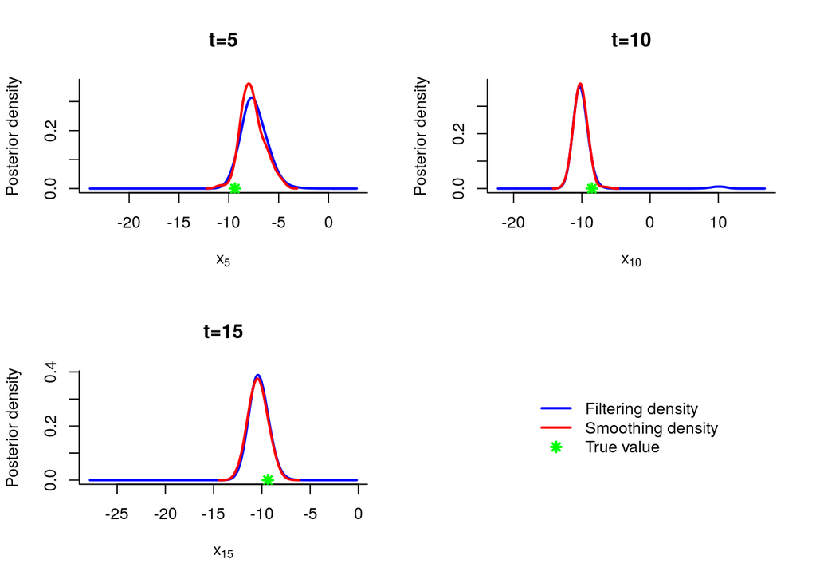

SMC: Marginal posteriors

```r
kde_smc = biips_density(out_smc)
time_index = c(5, 10, 15)
par(mfrow=c(2,2))
for (k in 1:length(time_index)) {
  tk = time_index[k]
  plot(kde_smc$x[[tk]], col=c('blue','red'), lwd=2,
       xlab=bquote(x[.(tk)]), ylab='Posterior density',
       main=paste('t=', tk, sep=''))
  points(data$x_true[tk], 0, col='green', pch=8, lwd=2)
}
plot(0, type='n', bty='n', xaxt='n', yaxt='n', xlab="", ylab="")
legend('center', leg=c('Filtering density', 'Smoothing density', 'True value'),
       col=c('blue', 'red', 'green'), pch=c(NA,NA,8), lty=c(1,1,NA), lwd=2,
       bty='n')
par(mfrow=c(1,1))
```